# Advanced Analysis and Model Refinement: Telehealth Hypertension Analytics

**Student:** Raja Chakraborty **Course:** DSC-590: Data Science Capstone **Institution:** College of Science, Engineering, and Technology, Grand Canyon University **Instructor:** Jonathan Pollyn **Date:** October 7, 2026 (revised for the Topic 7 audit; first issued September 30, 2026) **Repository:** https://github.com/rajachakraborti/telehealth-hypertension-analytics (release tag `topic7-submission`)

This notebook is the executable companion to the written report. Every table, figure, and number in the report is produced by the cells below (fixed random seed, so results are reproducible). It covers:

1. A synthetic 24-hour ambulatory blood pressure monitoring (ABPM) cohort with half-hourly readings, measurement noise, artifacts, missing readings, and a simulated office spot-check.
2. Benchmarks: an office-reading AHA rule, a guideline ABPM-threshold rule, logistic regression, and default XGBoost.
3. **Model selection by cross-validation on the 70% training set only** (Section 5): decision rules are fixed first, then three refinements (feature engineering, hyperparameter search, isotonic calibration) and one follow-up (morning-surge features) are judged against them. The 30% holdout is never used to choose anything. Holdout scores are reported afterwards for description.
4. Exploratory analysis of circadian profiles, morning surge, office-versus-ABPM discordance, feature attributions, and boundary errors.

## 1. Environment setup

```python
import json, os, platform, time, warnings
import numpy as np
import pandas as pd
import matplotlib.pyplot as plt
from scipy.stats import loguniform, randint, uniform
from sklearn.base import clone
from sklearn.calibration import CalibratedClassifierCV
from sklearn.linear_model import LogisticRegression
from sklearn.metrics import (accuracy_score, average_precision_score, confusion_matrix,
                             f1_score, precision_recall_fscore_support, roc_auc_score, roc_curve)
from sklearn.model_selection import (RandomizedSearchCV, RepeatedStratifiedKFold,
                                     StratifiedKFold, cross_val_score, train_test_split)
from sklearn.pipeline import make_pipeline
from sklearn.preprocessing import StandardScaler
import xgboost as xgb
import shap

warnings.filterwarnings("ignore")
RANDOM_STATE = 42
rng = np.random.default_rng(RANDOM_STATE)
OUT = "artifacts/topic6"  # figures and metrics
os.makedirs(OUT, exist_ok=True)

STAGES = ["Normal", "Elevated", "Stage 1", "Stage 2"]
STAGE_COLORS = ["#8fb8ea", "#4f8fdc", "#2a5fae", "#14306b"]  # ordinal: light to dark
BEFORE, AFTER = "#eb6834", "#2a78d6"
plt.rcParams.update({"font.family": "sans-serif", "font.size": 10, "axes.spines.top": False,
                     "axes.spines.right": False, "axes.grid": True, "grid.color": "#e6e6e3",
                     "grid.linewidth": 0.6, "axes.edgecolor": "#8a8984", "figure.dpi": 110,
                     "savefig.dpi": 200, "savefig.bbox": "tight", "legend.frameon": False})
metrics = {}
print("xgboost", xgb.__version__, "| shap", shap.__version__)
```

```
xgboost 2.0.3 | shap 0.49.1
```

## 2. Synthetic ABPM cohort

Real patient records are protected under HIPAA, so the cohort is simulated. Compared with the earlier phase (which generated one summary row per patient), each patient now has **48 half-hourly readings** over 24 hours, which makes circadian analysis possible. Generator assumptions:

- **Label** = the patient's adjudicated stage, i.e. their *long-run* blood pressure state (450 patients per stage, matching earlier phases).
- **Day-to-day variability:** the recorded day differs from the long-run state by N(0, 5) mmHg systolic, so a single monitoring day is an imperfect window on the true stage.
- **Sleep and wake:** diary bedtime ~N(22.5 h, 0.6) and wake time ~N(6.5 h, 0.6); nocturnal dip ratio varies by stage (normal dippers 12–18%, Stage 2 from -2% to 6%).
- **Morning surge:** a post-waking rise whose amplitude grows modestly with stage, an assumption drawn from Kario et al. (2003).
- **Measurement:** reading noise SD 6/4 mmHg, 3% cuff/motion artifacts of ±20–40 mmHg, 8% missing readings.
- **Office spot-check:** one clinic reading including a white-coat effect ~N(+4, 7) mmHg, so some patients read high in clinic (white-coat) and some read low (masked).

Because the morning surge and dipping differences are *built into the generator*, any analysis that "finds" them is checking that the pipeline works. It is not a clinical discovery. The report discusses this.

```python
N_PER = 450
spec = {  # long-run daytime SBP/DBP mean, sd; dip range; surge mean
    0: dict(sbp=(112, 5), dbp=(74, 4), dip=(0.12, 0.18), surge=8),
    1: dict(sbp=(124, 3), dbp=(76, 3), dip=(0.08, 0.14), surge=10),
    2: dict(sbp=(134, 4), dbp=(84, 4), dip=(0.04, 0.10), surge=13),
    3: dict(sbp=(156, 12), dbp=(98, 8), dip=(-0.02, 0.06), surge=17),
}
t = np.arange(0, 24, 0.5)  # 48 half-hourly slots
sig = lambda x: 1 / (1 + np.exp(-x))

rows, readings = [], []
pid = 0
for stage, s in spec.items():
    for _ in range(N_PER):
        sbp_true = rng.normal(*s["sbp"]); dbp_true = rng.normal(*s["dbp"])
        day_eff = rng.normal(0, 5)
        dip = rng.uniform(*s["dip"])
        surge = max(0, rng.normal(s["surge"], 5))
        bed, wake = rng.normal(22.5, 0.6), rng.normal(6.5, 0.6)
        hr_mean = rng.normal(74, 8)
        # smooth asleep indicator (1 = asleep), wrapping midnight
        tt = np.where(t < 12, t + 24, t)
        asleep = sig((tt - bed) * 3) * sig((wake + 24 - tt) * 3)
        surge_curve = surge * np.exp(-((t - (wake + 1.5)) ** 2) / (2 * 1.2 ** 2))
        sbp_level = sbp_true + day_eff
        dbp_level = dbp_true + 0.6 * day_eff
        sbp = sbp_level * (1 - dip * asleep) + surge_curve + rng.normal(0, 6, t.size)
        dbp = dbp_level * (1 - dip * asleep) + 0.5 * surge_curve + rng.normal(0, 4, t.size)
        hr = hr_mean * (1 - 0.10 * asleep) + rng.normal(0, 4, t.size)
        art = rng.random(t.size) < 0.03
        sbp[art] += rng.choice([-1, 1], art.sum()) * rng.uniform(20, 40, art.sum())
        miss = rng.random(t.size) < 0.08
        sbp[miss] = dbp[miss] = hr[miss] = np.nan
        wce = rng.normal(4, 7)
        rows.append(dict(pid=pid, target=stage, age=float(np.clip(rng.normal(56, 12), 21, 88)),
                         bmi=float(np.clip(rng.normal(27.5, 4.5), 18.5, 42)),
                         sex=rng.choice(["F", "M"]), wake=wake, bed=bed,
                         office_sbp=sbp_level + wce + rng.normal(0, 6),
                         office_dbp=dbp_level + 0.5 * wce + rng.normal(0, 4)))
        readings.append(pd.DataFrame(dict(pid=pid, hour=t, sbp=sbp, dbp=dbp, hr=hr,
                                          awake=asleep < 0.5)))
        pid += 1

patients = pd.DataFrame(rows)
abpm = pd.concat(readings, ignore_index=True)
print(f"{len(patients):,} patients, {len(abpm):,} half-hourly readings "
      f"({abpm.sbp.isna().mean():.1%} missing)")
patients.groupby("target").size().rename(index=dict(enumerate(STAGES)))
```

```
1,800 patients, 86,400 half-hourly readings (7.9% missing)
```

```
target
Normal      450
Elevated    450
Stage 1     450
Stage 2     450
dtype: int64
```

## 3. Feature extraction from the 24-hour record

Summary features (the earlier phase's inputs) are computed from the noisy readings using the patient's diary sleep/wake times. Morning-surge features follow Kario et al. (2003): **sleep-trough surge** = mean SBP in the 2 h after waking minus the mean of the lowest night reading and its two neighbours; **pre-waking surge** = mean SBP in the 2 h after waking minus the mean in the 2 h before waking. Because both conventional definitions include the night-to-day transition, they also absorb nocturnal dipping, so a third, **dip-adjusted surge excess** = mean SBP in the 2 h after waking minus the patient's daytime mean is also computed.

```python
def summarize(g, wake):
    day, night = g[g.awake], g[~g.awake]
    hrs_after = (g.hour - wake) % 24
    morning = g[hrs_after < 2].sbp.mean()
    prewake = g[(hrs_after >= 22)].sbp.mean()
    ns = night.sbp.dropna().values
    k = int(np.nanargmin(ns)) if ns.size else 0
    trough = ns[max(0, k - 1):k + 2].mean() if ns.size else np.nan
    return pd.Series(dict(sbp_day=day.sbp.mean(), dbp_day=day.dbp.mean(),
                          sbp_night=night.sbp.mean(), dbp_night=night.dbp.mean(),
                          heart_rate=g.hr.mean(), surge_sleep_trough=morning - trough,
                          surge_prewake=morning - prewake,
                          surge_excess=morning - day.sbp.mean()))

feats = abpm.groupby("pid").apply(lambda g: summarize(g, patients.wake.iloc[g.name]))
df = patients.join(feats, on="pid")

def engineer(d):
    d = d.copy()
    d["map_day"] = d.dbp_day + (d.sbp_day - d.dbp_day) / 3
    d["map_night"] = d.dbp_night + (d.sbp_night - d.dbp_night) / 3
    d["pulse_pressure"] = d.sbp_day - d.dbp_day
    d["dip_ratio"] = (d.sbp_day - d.sbp_night) / d.sbp_day
    return d

df = engineer(df)
RAW = ["sbp_day", "dbp_day", "sbp_night", "dbp_night", "heart_rate", "age", "bmi"]
ENG = RAW + ["map_day", "map_night", "pulse_pressure", "dip_ratio"]
SURGE = ENG + ["surge_sleep_trough", "surge_prewake", "surge_excess"]
df[RAW + ["dip_ratio", "surge_sleep_trough"]].describe().round(1)
```

|  | sbp_day | dbp_day | sbp_night | dbp_night | heart_rate | age | bmi | dip_ratio | surge_sleep_trough |
| --- | --- | --- | --- | --- | --- | --- | --- | --- | --- |
| count | 1800.0 | 1800.0 | 1800.0 | 1800.0 | 1800.0 | 1800.0 | 1800.0 | 1800.0 | 1800.0 |
| mean | 133.3 | 83.7 | 121.8 | 76.7 | 71.6 | 55.9 | 27.7 | 0.1 | 23.7 |
| std | 19.0 | 11.7 | 22.9 | 14.1 | 7.9 | 12.2 | 4.5 | 0.0 | 8.3 |
| min | 93.3 | 57.7 | 78.0 | 48.1 | 43.4 | 21.0 | 18.5 | -0.0 | -3.6 |
| 25% | 119.4 | 75.3 | 104.0 | 66.1 | 66.6 | 47.4 | 24.5 | 0.1 | 18.4 |
| 50% | 130.2 | 81.0 | 118.4 | 73.3 | 71.6 | 56.3 | 27.6 | 0.1 | 23.3 |
| 75% | 143.2 | 90.2 | 135.6 | 85.8 | 76.8 | 64.0 | 30.8 | 0.1 | 28.8 |
| max | 200.9 | 131.8 | 192.9 | 129.5 | 104.0 | 88.0 | 41.9 | 0.2 | 58.1 |

## 4. Holdout split and evaluation helpers

A stratified 30% holdout (540 patients) is set aside before any tuning or calibration. **It plays no part in choosing the model.** Every selection decision in Section 5 uses cross-validation inside the 70% training set (1,260 patients). The holdout is used afterwards to describe the performance of the chosen pipeline and its comparators. (An earlier version of this notebook fitted the calibrator on the test set, which leaks information, and a later revision still used holdout metrics to keep or drop refinements. Both are fixed here.)

```python
train_idx, test_idx = train_test_split(df.index, test_size=0.30, stratify=df.target,
                                       random_state=RANDOM_STATE)
tr, te = df.loc[train_idx], df.loc[test_idx]
y_tr, y_te = tr.target.values, te.target.values
Y_te = np.eye(4)[y_te]

def ece_top_label(y, P, bins=10):
    conf, pred = P.max(1), P.argmax(1)
    edges = np.linspace(0, 1, bins + 1)
    e = 0.0
    for lo, hi in zip(edges[:-1], edges[1:]):
        m = (conf > lo) & (conf <= hi)
        if m.any():
            e += m.mean() * abs((pred[m] == y[m]).mean() - conf[m].mean())
    return e

def evaluate(name, pred, P=None):
    p, r, f, _ = precision_recall_fscore_support(y_te, pred, labels=range(4), zero_division=0)
    cm = confusion_matrix(y_te, pred, labels=range(4))
    spec_ = [(cm.sum() - cm[i].sum() - cm[:, i].sum() + cm[i, i]) / (cm.sum() - cm[i].sum())
             for i in range(4)]
    out = dict(name=name, accuracy=accuracy_score(y_te, pred), macro_f1=f.mean(),
               crisis_recall=r[3], precision=p.tolist(), recall=r.tolist(), f1=f.tolist(),
               specificity=spec_, cm=cm.tolist())
    if P is not None:
        out.update(roc_auc=[roc_auc_score(Y_te[:, i], P[:, i]) for i in range(4)],
                   pr_auc=[average_precision_score(Y_te[:, i], P[:, i]) for i in range(4)],
                   brier=float(np.mean(np.sum((P - Y_te) ** 2, axis=1))),
                   ece=ece_top_label(y_te, P))
        out["macro_roc_auc"] = float(np.mean(out["roc_auc"]))
    return out

def latency_ms(fn, X, n=300):
    row = X.iloc[[0]]
    fn(row)
    ts = []
    for i in range(n):
        r = X.iloc[[i % len(X)]]
        t0 = time.perf_counter(); fn(r); ts.append((time.perf_counter() - t0) * 1000)
    return float(np.median(ts))

def boot_ci(pred, stat, n=1000, seed=RANDOM_STATE):
    g = np.random.default_rng(seed); vals = []
    for _ in range(n):
        i = g.integers(0, len(y_te), len(y_te))
        vals.append(stat(y_te[i], pred[i]))
    return [float(np.percentile(vals, 2.5)), float(np.percentile(vals, 97.5))]
```

## 5. Model selection by cross-validation (training set only)

**Decision rules, fixed before any result is looked at.** Each candidate is compared with its reference on the same folds (3 repeats of stratified 5-fold CV = 15 folds). The criterion is mean multi-class **log loss**, a proper scoring rule that rewards honest probabilities. For each candidate the paired fold difference is summarized as a z-score (mean gain divided by its standard error; positive means the candidate is better).

1. **Adopt** the candidate if it lowers log loss by at least 2 standard errors.
2. **Reject** it if it raises log loss by at least 2 standard errors, or multiplies inference cost by 3x or more without a supported gain.
3. Otherwise there is **no supported difference**. Optional add-ons (calibration, morning-surge features) are not adopted, for parsimony. The clinically defined feature set (mean arterial pressure, pulse pressure, nocturnal dipping ratio) is the project's design baseline, so it is kept if it is not worse than raw features and its value is reported as interpretability, not accuracy.

Brier score and expected calibration error (ECE) are reported alongside but do not drive the decision. Caveats: repeated folds share training data, so the standard errors are somewhat too small and the 2-SE threshold is a mild criterion; the tuned settings were found by search on these same folds, so a **nested** cross-validation (search repeated inside each outer fold) is added to check that the tuning gain is not an artifact of selecting and scoring on the same folds.

```python
# Refinement 2 search, run here so that every selection step precedes any holdout scoring.
# Randomized search (Bergstra & Bengio, 2012): 40 candidates, 5-fold stratified CV on the
# training set only, optimizing multi-class log loss.
SEARCH_SPACE = {"max_depth": randint(2, 8), "learning_rate": loguniform(0.01, 0.3),
                "n_estimators": randint(100, 600), "subsample": uniform(0.6, 0.4),
                "colsample_bytree": uniform(0.5, 0.5), "min_child_weight": randint(1, 10),
                "reg_lambda": loguniform(0.1, 10)}
search = RandomizedSearchCV(
    xgb.XGBClassifier(random_state=RANDOM_STATE, eval_metric="mlogloss"), SEARCH_SPACE,
    n_iter=40, scoring="neg_log_loss", cv=StratifiedKFold(5, shuffle=True, random_state=RANDOM_STATE),
    random_state=RANDOM_STATE, n_jobs=1)
search.fit(tr[ENG], y_tr)
xgb_tuned = search.best_estimator_
best_params = {k: (round(float(v), 4) if isinstance(v, float) else int(v))
               for k, v in search.best_params_.items()}
best_params
```

```
{'colsample_bytree': 0.9989,
 'learning_rate': 0.0248,
 'max_depth': 3,
 'min_child_weight': 2,
 'n_estimators': 319,
 'reg_lambda': 0.1268,
 'subsample': 0.7115}
```

```python
from sklearn.metrics import log_loss
import xgboost as xgb

def make_xgb(**kw):
    return xgb.XGBClassifier(random_state=RANDOM_STATE, eval_metric="mlogloss", **kw)

def cv_candidate(make, cols, n_rep=3):
    """Out-of-fold scores on the training set: n_rep x 5 stratified folds."""
    rows = []
    for r in range(n_rep):
        for k, (a, b) in enumerate(StratifiedKFold(5, shuffle=True, random_state=RANDOM_STATE + r).split(tr, y_tr)):
            m = make().fit(tr.iloc[a][cols], y_tr[a])
            t0 = time.perf_counter(); P = m.predict_proba(tr.iloc[b][cols])
            ms = (time.perf_counter() - t0) * 1000 / len(b)
            yb = y_tr[b]
            rows.append(dict(rep=r, fold=k, logloss=log_loss(yb, P, labels=range(4)),
                             brier=float(np.mean(np.sum((P - np.eye(4)[yb]) ** 2, axis=1))),
                             ece=ece_top_label(yb, P), accuracy=float((P.argmax(1) == yb).mean()),
                             ms_per_patient=ms))
    return pd.DataFrame(rows)

CANDIDATES = {
    "default_raw":   (lambda: make_xgb(), RAW),
    "default_eng":   (lambda: make_xgb(), ENG),
    "tuned_eng":     (lambda: make_xgb(**search.best_params_), ENG),
    "tuned_eng_iso": (lambda: CalibratedClassifierCV(make_xgb(**search.best_params_), method="isotonic", cv=5), ENG),
    "tuned_surge":   (lambda: make_xgb(**search.best_params_), SURGE),
}
cvres = {k: cv_candidate(mk, cols) for k, (mk, cols) in CANDIDATES.items()}

def paired(ref, cand):
    out = {}
    for m in ["logloss", "brier", "ece"]:
        d = cvres[ref][m].values - cvres[cand][m].values          # positive = candidate better
        se = d.std(ddof=1) / np.sqrt(len(d))
        out[m] = dict(gain=float(d.mean()), se=float(se), z=float(d.mean() / se))
    out["rel_cost"] = float(cvres[cand].ms_per_patient.mean() / cvres[ref].ms_per_patient.mean())
    return out

COMPARISONS = {  # step: (reference, candidate)
    "feature_engineering": ("default_raw", "default_eng"),
    "hyperparameter_search": ("default_eng", "tuned_eng"),
    "isotonic_calibration": ("tuned_eng", "tuned_eng_iso"),
    "morning_surge_features": ("tuned_eng", "tuned_surge"),
}
cmp_ = {step: paired(*pair) for step, pair in COMPARISONS.items()}

table = pd.DataFrame({k: dict(logloss=v.logloss.mean(), logloss_sd=v.logloss.std(), brier=v.brier.mean(),
                              ece=v.ece.mean(), accuracy=v.accuracy.mean()) for k, v in cvres.items()}).T
display(table.round(4))
display(pd.DataFrame({s: dict(logloss_gain=c["logloss"]["gain"], se=c["logloss"]["se"], z=c["logloss"]["z"],
                              brier_gain=c["brier"]["gain"], ece_gain=c["ece"]["gain"], rel_cost=c["rel_cost"])
                      for s, c in cmp_.items()}).T.round(4))
```

|  | logloss | logloss_sd | brier | ece | accuracy |
| --- | --- | --- | --- | --- | --- |
| default_raw | 0.4555 | 0.0850 | 0.2199 | 0.0926 | 0.8627 |
| default_eng | 0.4485 | 0.0868 | 0.2158 | 0.0917 | 0.8624 |
| tuned_eng | 0.3038 | 0.0485 | 0.1792 | 0.0431 | 0.8706 |
| tuned_eng_iso | 0.4014 | 0.1529 | 0.1773 | 0.0351 | 0.8698 |
| tuned_surge | 0.3026 | 0.0495 | 0.1774 | 0.0372 | 0.8741 |

|  | logloss_gain | se | z | brier_gain | ece_gain | rel_cost |
| --- | --- | --- | --- | --- | --- | --- |
| feature_engineering | 0.0070 | 0.0111 | 0.6357 | 0.0042 | 0.0009 | 1.0287 |
| hyperparameter_search | 0.1447 | 0.0124 | 11.6889 | 0.0366 | 0.0486 | 1.1615 |
| isotonic_calibration | -0.0976 | 0.0311 | -3.1374 | 0.0019 | 0.0080 | 5.1181 |
| morning_surge_features | 0.0011 | 0.0016 | 0.7049 | 0.0018 | 0.0059 | 1.0612 |

```python
# Nested CV for the tuning step: the whole search is repeated inside each outer training fold,
# so the outer fold that is scored never influenced the settings chosen.
nested, base = [], []
for a, b in StratifiedKFold(5, shuffle=True, random_state=RANDOM_STATE).split(tr, y_tr):
    inner = RandomizedSearchCV(
        make_xgb(n_jobs=1), SEARCH_SPACE, n_iter=40, scoring="neg_log_loss",
        cv=StratifiedKFold(5, shuffle=True, random_state=RANDOM_STATE),
        random_state=RANDOM_STATE, n_jobs=-1).fit(tr.iloc[a][ENG], y_tr[a])
    nested.append(log_loss(y_tr[b], inner.predict_proba(tr.iloc[b][ENG]), labels=range(4)))
    base.append(log_loss(y_tr[b], make_xgb().fit(tr.iloc[a][ENG], y_tr[a]).predict_proba(tr.iloc[b][ENG]),
                         labels=range(4)))
d = np.array(base) - np.array(nested)
nested_cv = dict(default_logloss=float(np.mean(base)), tuned_logloss=float(np.mean(nested)),
                 gain=float(d.mean()), se=float(d.std(ddof=1) / np.sqrt(len(d))), folds=len(d))
nested_cv
```

```
{'default_logloss': 0.4424382608942392,
 'tuned_logloss': 0.3050227818367292,
 'gain': 0.13741547905750995,
 'se': 0.019021815583373,
 'folds': 5}
```

```python
def decide(c, baseline=False):
    z, cost = c["logloss"]["z"], c["rel_cost"]
    if z >= 2:
        return "ADOPT"
    if z <= -2 or cost >= 3:
        return "REJECT"
    return "RETAIN (design baseline)" if baseline else "NOT ADOPTED (no supported gain)"

decisions = {
    "feature_engineering": decide(cmp_["feature_engineering"], baseline=True),
    "hyperparameter_search": decide(cmp_["hyperparameter_search"]),
    "isotonic_calibration": decide(cmp_["isotonic_calibration"]),
    "morning_surge_features": decide(cmp_["morning_surge_features"]),
}
if nested_cv["gain"] / nested_cv["se"] < 2:   # tuning must also survive the nested check
    decisions["hyperparameter_search"] = "NOT ADOPTED (fails nested check)"

# Everything below is built for this outcome; stop if the evidence ever says otherwise.
assert decisions == {"feature_engineering": "RETAIN (design baseline)", "hyperparameter_search": "ADOPT",
                     "isotonic_calibration": "REJECT",
                     "morning_surge_features": "NOT ADOPTED (no supported gain)"}, decisions

metrics["selection"] = dict(
    rule="adopt if CV log-loss gain >= 2 SE; reject if <= -2 SE or >= 3x cost; else not adopted (baseline retained)",
    folds="3 x 5 stratified CV on the 1,260-patient training set",
    candidates={k: {m: [float(v[m].mean()), float(v[m].std())] for m in ["logloss", "brier", "ece", "accuracy"]}
                for k, v in cvres.items()},
    comparisons=cmp_, nested_cv=nested_cv, decisions=decisions,
    environment=dict(python=platform.python_version(), xgboost=xgb.__version__, shap=shap.__version__))
pd.Series(decisions)
```

```
feature_engineering              RETAIN (design baseline)
hyperparameter_search                               ADOPT
isotonic_calibration                               REJECT
morning_surge_features    NOT ADOPTED (no supported gain)
dtype: object
```

## 5. Benchmarks

- **Office AHA rule:** 2017 ACC/AHA office thresholds applied to a single clinic reading (Whelton et al., 2018). Guidelines actually recommend averaging two or more readings on two or more occasions, so this is a deliberately simple stand-in for spot-check practice.
- **ABPM guideline rule:** daytime ABPM thresholds that correspond to the office categories (120/80, 130/80, 135/85; Whelton et al., 2018, Table 11) applied to the 24-hour record. This is the strongest non-ML benchmark because it uses the same data the model sees.
- **Logistic regression** (standardized raw features) and **default XGBoost** (raw features).

```python
def aha_rule(s, d, cut2=(140, 90), cut1=(130, 80)):
    return np.select([(s >= cut2[0]) | (d >= cut2[1]), (s >= cut1[0]) | (d >= cut1[1]),
                      (s >= 120) & (d < 80)], [3, 2, 1], 0)

pred_office = aha_rule(te.office_sbp.values, te.office_dbp.values)
pred_abpm = aha_rule(te.sbp_day.values, te.dbp_day.values, cut2=(135, 85))

lr = make_pipeline(StandardScaler(), LogisticRegression(max_iter=2000))
lr.fit(tr[RAW], y_tr)
xgb_default = xgb.XGBClassifier(random_state=RANDOM_STATE, eval_metric="mlogloss")
xgb_default.fit(tr[RAW], y_tr)

res = {}
res["office_rule"] = evaluate("Office AHA rule (single reading)", pred_office)
res["abpm_rule"] = evaluate("ABPM guideline rule (daytime mean)", pred_abpm)
res["logreg"] = evaluate("Logistic regression", lr.predict(te[RAW]), lr.predict_proba(te[RAW]))
P_default = xgb_default.predict_proba(te[RAW])
res["xgb_default"] = evaluate("Default XGBoost", P_default.argmax(1), P_default)
res["office_rule"]["latency_ms"] = res["abpm_rule"]["latency_ms"] = latency_ms(
    lambda r: aha_rule(r.sbp_day.values, r.dbp_day.values), te)
res["logreg"]["latency_ms"] = latency_ms(lambda r: lr.predict_proba(r[RAW]), te)
res["xgb_default"]["latency_ms"] = latency_ms(lambda r: xgb_default.predict_proba(r[RAW]), te)

pd.DataFrame(res).T[["accuracy", "macro_f1", "crisis_recall", "macro_roc_auc", "brier", "ece",
                      "latency_ms"]].astype(float).round(3)
```

|  | accuracy | macro_f1 | crisis_recall | macro_roc_auc | brier | ece | latency_ms |
| --- | --- | --- | --- | --- | --- | --- | --- |
| office_rule | 0.543 | 0.521 | 0.956 | NaN | NaN | NaN | 0.168 |
| abpm_rule | 0.615 | 0.588 | 0.993 | NaN | NaN | NaN | 0.168 |
| logreg | 0.883 | 0.884 | 0.948 | 0.98 | 0.182 | 0.056 | 2.197 |
| xgb_default | 0.889 | 0.889 | 0.970 | 0.98 | 0.181 | 0.076 | 3.335 |

## 6. Refinement steps: holdout description

Sections 5 chose the pipeline. The cells below show how each step behaves on the held-out patients, **for description only**: no decision on this page depends on these numbers.

**Refinement 1: feature engineering.** Add mean arterial pressure (day and night), pulse pressure, and the nocturnal dipping ratio. Default XGBoost hyperparameters are kept, so the change is isolated to features.

```python
xgb_fe = xgb.XGBClassifier(random_state=RANDOM_STATE, eval_metric="mlogloss")
xgb_fe.fit(tr[ENG], y_tr)
P_fe = xgb_fe.predict_proba(te[ENG])
res["xgb_fe"] = evaluate("+ Feature engineering", P_fe.argmax(1), P_fe)
res["xgb_fe"]["latency_ms"] = latency_ms(lambda r: xgb_fe.predict_proba(r[ENG]), te)
{k: round(res["xgb_fe"][k], 3) for k in ["accuracy", "macro_f1", "crisis_recall", "brier", "ece"]}
```

```
{'accuracy': 0.889,
 'macro_f1': 0.889,
 'crisis_recall': 0.97,
 'brier': 0.176,
 'ece': 0.065}
```

**Refinement 2: hyperparameter search.** The search itself (40 candidates, 5-fold stratified cross-validation on the training set, optimizing log loss) ran in Section 5. Below, the chosen settings are scored on the holdout and the fold-to-fold stability is compared.

```python
# (search and best_params come from Section 5)
P_tuned = xgb_tuned.predict_proba(te[ENG])
res["xgb_tuned"] = evaluate("+ Hyperparameter search", P_tuned.argmax(1), P_tuned)
res["xgb_tuned"]["latency_ms"] = latency_ms(lambda r: xgb_tuned.predict_proba(r[ENG]), te)

# Fold-to-fold stability before vs after tuning (5x3 repeated CV, training set only)
rcv = RepeatedStratifiedKFold(n_splits=5, n_repeats=3, random_state=RANDOM_STATE)
cv_before = cross_val_score(clone(xgb_fe), tr[ENG], y_tr, cv=rcv, scoring="neg_log_loss", n_jobs=1)
cv_after = cross_val_score(clone(xgb_tuned), tr[ENG], y_tr, cv=rcv, scoring="neg_log_loss", n_jobs=1)
cvf_before = cross_val_score(clone(xgb_fe), tr[ENG], y_tr, cv=rcv, scoring="f1_macro", n_jobs=1)
cvf_after = cross_val_score(clone(xgb_tuned), tr[ENG], y_tr, cv=rcv, scoring="f1_macro", n_jobs=1)
metrics["tuning"] = dict(best_params=best_params,
                         cv_logloss_before=[float(-cv_before.mean()), float(cv_before.std())],
                         cv_logloss_after=[float(-cv_after.mean()), float(cv_after.std())],
                         cv_f1_before=[float(cvf_before.mean()), float(cvf_before.std())],
                         cv_f1_after=[float(cvf_after.mean()), float(cvf_after.std())])
best_params, metrics["tuning"]
```

```
({'colsample_bytree': 0.9989,
  'learning_rate': 0.0248,
  'max_depth': 3,
  'min_child_weight': 2,
  'n_estimators': 319,
  'reg_lambda': 0.1268,
  'subsample': 0.7115},
 {'best_params': {'colsample_bytree': 0.9989,
   'learning_rate': 0.0248,
   'max_depth': 3,
   'min_child_weight': 2,
   'n_estimators': 319,
   'reg_lambda': 0.1268,
   'subsample': 0.7115},
  'cv_logloss_before': [0.44537788262331635, 0.057357438684505616],
  'cv_logloss_after': [0.3017228770861584, 0.038086399429530286],
  'cv_f1_before': [0.8676185355787175, 0.01427946113935369],
  'cv_f1_after': [0.8741498693033566, 0.016756141190511744]})
```

**Refinement 3: isotonic calibration (tested).** `CalibratedClassifierCV` with 5-fold internal cross-validation on the **training set**: each fold's tuned model is calibrated on data it did not see during fitting. Section 5 compared it with the uncalibrated tuned model by cross-validation; the holdout figures below are descriptive.

```python
xgb_cal = CalibratedClassifierCV(clone(xgb_tuned), method="isotonic", cv=5)
xgb_cal.fit(tr[ENG], y_tr)
P_cal = xgb_cal.predict_proba(te[ENG])
res["xgb_cal"] = evaluate("+ Isotonic calibration", P_cal.argmax(1), P_cal)
res["xgb_cal"]["latency_ms"] = latency_ms(lambda r: xgb_cal.predict_proba(r[ENG]), te)

explainer = shap.TreeExplainer(xgb_tuned)
res["xgb_tuned"]["shap_latency_ms"] = latency_ms(lambda r: explainer.shap_values(r[ENG]), te, n=100)

order = ["office_rule", "abpm_rule", "logreg", "xgb_default", "xgb_fe", "xgb_tuned", "xgb_cal"]
summary = pd.DataFrame([res[k] for k in order]).set_index("name")[
    ["accuracy", "macro_f1", "crisis_recall", "macro_roc_auc", "brier", "ece", "latency_ms"]]
summary.astype(float).round(3)
```

| name | accuracy | macro_f1 | crisis_recall | macro_roc_auc | brier | ece | latency_ms |
| --- | --- | --- | --- | --- | --- | --- | --- |
| Office AHA rule (single reading) | 0.543 | 0.521 | 0.956 | NaN | NaN | NaN | 0.168 |
| ABPM guideline rule (daytime mean) | 0.615 | 0.588 | 0.993 | NaN | NaN | NaN | 0.168 |
| Logistic regression | 0.883 | 0.884 | 0.948 | 0.980 | 0.182 | 0.056 | 2.197 |
| Default XGBoost | 0.889 | 0.889 | 0.970 | 0.980 | 0.181 | 0.076 | 3.335 |
| + Feature engineering | 0.889 | 0.889 | 0.970 | 0.980 | 0.176 | 0.065 | 4.166 |
| + Hyperparameter search | 0.902 | 0.902 | 0.970 | 0.984 | 0.148 | 0.014 | 4.178 |
| + Isotonic calibration | 0.900 | 0.900 | 0.970 | 0.982 | 0.152 | 0.024 | 25.412 |

**Decisions (from Section 5: cross-validation on the training set, rules fixed in advance).**

- **Feature engineering: retained as the design baseline, not as an improvement.** Log-loss gain +0.007 (SE 0.011, z = 0.6), so cross-validation finds no reliable difference from raw features. The engineered set is kept because mean arterial pressure and the dipping ratio are the quantities clinicians read and the explanations are given in those terms. (An earlier version of this notebook credited feature engineering with a calibration gain, based on holdout numbers; cross-validation does not support that.)
- **Hyperparameter search: adopted.** Gain +0.145 (SE 0.012, z = 11.7). Under nested cross-validation, where the whole search is repeated inside each training fold, the gain is +0.137 (SE 0.019), so it is not an artifact of choosing and scoring on the same folds.
- **Isotonic calibration: rejected.** Log loss gets worse by 0.098 (SE 0.031, z = -3.1): isotonic regression is a step function that can output probabilities near zero, which log loss punishes heavily. It also multiplies inference cost about 5x. In cross-validation Brier score is unchanged (z = 1.5) and ECE improves slightly (0.043 to 0.035, z = 2.7), and on the holdout Brier and ECE are slightly worse (descriptive only), so the evidence on calibration quality is mixed; the cost is not. A reviewer who weighted ECE above log loss could reasonably decide otherwise, but not at 5x the cost.
- **Morning-surge features: not adopted.** No supported log-loss gain (z = 0.7), although ECE improves a little (0.043 to 0.037). Under the preset rule they stay out; they are better tested for outcome prediction, where the clinical literature places their value.

The model carried forward is the feature-engineered, tuned XGBoost trained on the 1,260 training patients.

### Bootstrap confidence intervals (1,000 resamples of the holdout)

```python
crisis_rec = lambda y, p: ((p == 3) & (y == 3)).sum() / max((y == 3).sum(), 1)
macro_f1 = lambda y, p: f1_score(y, p, average="macro")
ci = {}
for k, pred in {"abpm_rule": pred_abpm, "logreg": lr.predict(te[RAW]),
                "xgb_default": P_default.argmax(1), "xgb_tuned": P_tuned.argmax(1)}.items():
    ci[k] = dict(accuracy=boot_ci(pred, accuracy_score), macro_f1=boot_ci(pred, macro_f1),
                 crisis_recall=boot_ci(pred, crisis_rec))
# paired difference: calibrated pipeline minus each comparator
g = np.random.default_rng(RANDOM_STATE)
for ref, pref in [("xgb_default", P_default.argmax(1)), ("abpm_rule", pred_abpm),
                  ("logreg", lr.predict(te[RAW]))]:
    d = []
    for _ in range(1000):
        i = g.integers(0, len(y_te), len(y_te))
        d.append(accuracy_score(y_te[i], P_tuned.argmax(1)[i]) - accuracy_score(y_te[i], pref[i]))
    ci[f"acc_diff_vs_{ref}"] = [float(np.percentile(d, 2.5)), float(np.percentile(d, 97.5))]
metrics["ci"] = ci
ci
```

```
{'abpm_rule': {'accuracy': [0.575925925925926, 0.6592592592592592],
  'macro_f1': [0.552563332262609, 0.6287493703819215],
  'crisis_recall': [0.9765578863188976, 1.0]},
 'logreg': {'accuracy': [0.8555555555555555, 0.9074074074074074],
  'macro_f1': [0.8550237919937655, 0.9081715818584591],
  'crisis_recall': [0.9078924038820456, 0.979173801369863]},
 'xgb_default': {'accuracy': [0.8592592592592593, 0.9148148148148149],
  'macro_f1': [0.8608690314422773, 0.9139171735355074],
  'crisis_recall': [0.9379723837209303, 0.9929589776420762]},
 'xgb_tuned': {'accuracy': [0.8740277777777778, 0.9259259259259259],
  'macro_f1': [0.874094444339795, 0.9262202001275329],
  'crisis_recall': [0.937984496124031, 0.9929601917057903]},
 'acc_diff_vs_xgb_default': [-0.005555555555555538, 0.031481481481481555],
 'acc_diff_vs_abpm_rule': [0.24259259259259258, 0.32777777777777783],
 'acc_diff_vs_logreg': [-0.0018518518518518823, 0.03703703703703698]}
```

### Figure 1: Confusion matrices before and after refinement

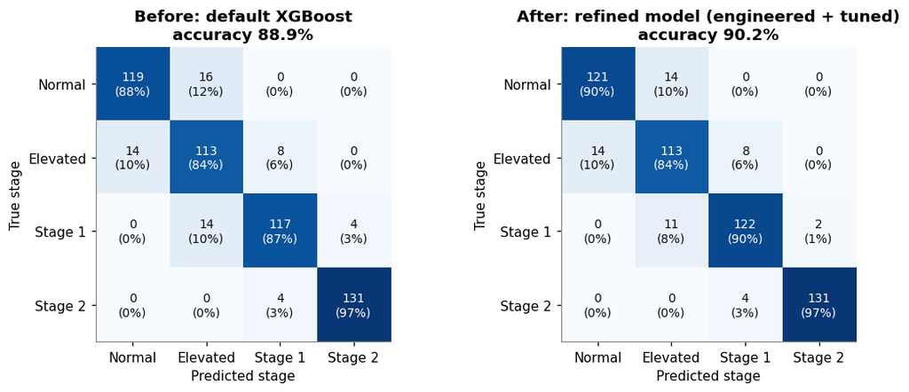

```python
fig, axes = plt.subplots(1, 2, figsize=(10, 4.2))
for ax, key, title in [(axes[0], "xgb_default", "Before: default XGBoost"),
                       (axes[1], "xgb_tuned", "After: refined model (engineered + tuned)")]:
    cm = np.array(res[key]["cm"])
    ax.imshow(cm / cm.sum(1, keepdims=True), cmap="Blues", vmin=0, vmax=1)
    for i in range(4):
        for j in range(4):
            v = cm[i, j] / cm[i].sum()
            ax.text(j, i, f"{cm[i, j]}\n({v:.0%})", ha="center", va="center", fontsize=9,
                    color="white" if v > 0.55 else "#0b0b0b")
    ax.set_xticks(range(4), STAGES); ax.set_yticks(range(4), STAGES)
    ax.set_xlabel("Predicted stage"); ax.set_ylabel("True stage"); ax.grid(False)
    ax.set_title(f"{title}\naccuracy {res[key]['accuracy']:.1%}", fontweight="bold")
plt.tight_layout(); plt.savefig(f"{OUT}/topic6_fig1_confusion.png"); plt.show()
```

### Figure 2: Metric progression across refinement steps (holdout, descriptive)

Selection used cross-validation (Section 5); this figure only shows how the steps look on unseen patients.

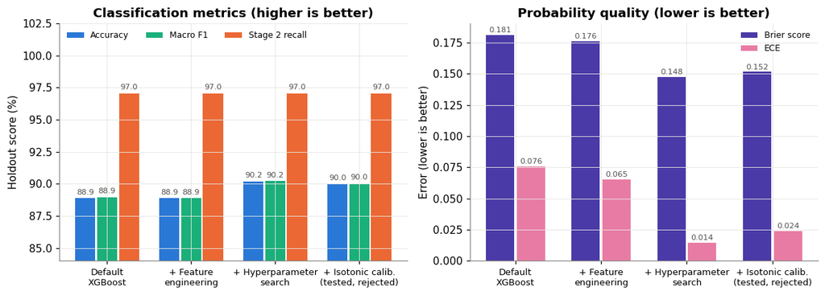

```python
steps = ["xgb_default", "xgb_fe", "xgb_tuned", "xgb_cal"]
labels = ["Default\nXGBoost", "+ Feature\nengineering", "+ Hyperparameter\nsearch", "+ Isotonic calib.\n(tested, rejected)"]
fig, (a1, a2) = plt.subplots(1, 2, figsize=(11, 4))
x = np.arange(4); w = 0.26
for k, (m, lab, c) in enumerate([("accuracy", "Accuracy", "#2a78d6"),
                                  ("macro_f1", "Macro F1", "#1baf7a"),
                                  ("crisis_recall", "Stage 2 recall", "#eb6834")]):
    vals = [res[s][m] * 100 for s in steps]
    a1.bar(x + (k - 1) * w, vals, w * 0.92, label=lab, color=c)
    for xi, v in zip(x + (k - 1) * w, vals):
        a1.text(xi, v + 0.3, f"{v:.1f}", ha="center", fontsize=7.5, color="#52514e")
lo = min(res[s][m] for s in steps for m in ["accuracy", "macro_f1", "crisis_recall"]) * 100
a1.set_ylim(np.floor(lo) - 4, 102.5); a1.set_xticks(x, labels, fontsize=8.5)
a1.set_ylabel("Holdout score (%)"); a1.legend(loc="upper left", ncol=3, fontsize=8)
a1.set_title("Classification metrics (higher is better)", fontweight="bold")
for k, (m, lab, c) in enumerate([("brier", "Brier score", "#4a3aa7"), ("ece", "ECE", "#e87ba4")]):
    vals = [res[s][m] for s in steps]
    a2.bar(x + (k - 0.5) * 0.36, vals, 0.33, label=lab, color=c)
    for xi, v in zip(x + (k - 0.5) * 0.36, vals):
        a2.text(xi, v + 0.002, f"{v:.3f}", ha="center", fontsize=7.5, color="#52514e")
a2.set_xticks(x, labels, fontsize=8.5); a2.set_ylabel("Error (lower is better)")
a2.legend(fontsize=8); a2.set_title("Probability quality (lower is better)", fontweight="bold")
plt.tight_layout(); plt.savefig(f"{OUT}/topic6_fig2_progression.png"); plt.show()
```

### Figure 3: One-vs-rest ROC curves before and after refinement

[figure not shown]

```python
fig, axes = plt.subplots(1, 2, figsize=(10.5, 4.4), sharey=True)
for ax, P, key, title in [(axes[0], P_default, "xgb_default", "Before: default XGBoost"),
                          (axes[1], P_tuned, "xgb_tuned", "After: refined model (engineered + tuned)")]:
    for i in range(4):
        fpr, tpr, _ = roc_curve(Y_te[:, i], P[:, i])
        ax.step(fpr, tpr, where="post", lw=2, color=STAGE_COLORS[i],
                label=f"{STAGES[i]} (AUC {res[key]['roc_auc'][i]:.3f})")
    ax.plot([0, 1], [0, 1], ls="--", color="#8a8984", lw=1, label="Chance (AUC 0.5)")
    ax.set_xlim(-0.01, 1); ax.set_ylim(0, 1.01); ax.set_xlabel("False positive rate")
    ax.set_title(f"{title}\nmacro AUC {res[key]['macro_roc_auc']:.3f}", fontweight="bold")
    ax.legend(loc="lower right", fontsize=8)
    ins = ax.inset_axes([0.42, 0.42, 0.5, 0.33])
    for i in range(4):
        fpr, tpr, _ = roc_curve(Y_te[:, i], P[:, i])
        ins.step(fpr, tpr, where="post", lw=1.5, color=STAGE_COLORS[i])
    ins.set_xlim(0, 0.2); ins.set_ylim(0.6, 1.0); ins.tick_params(labelsize=7)
    ins.set_title("zoom: FPR 0-0.2", fontsize=7)
axes[0].set_ylabel("True positive rate")
plt.tight_layout(); plt.savefig(f"{OUT}/topic6_fig3_roc.png"); plt.show()
```

### Figure 4: Reliability diagram (top-label confidence) across refinement stages

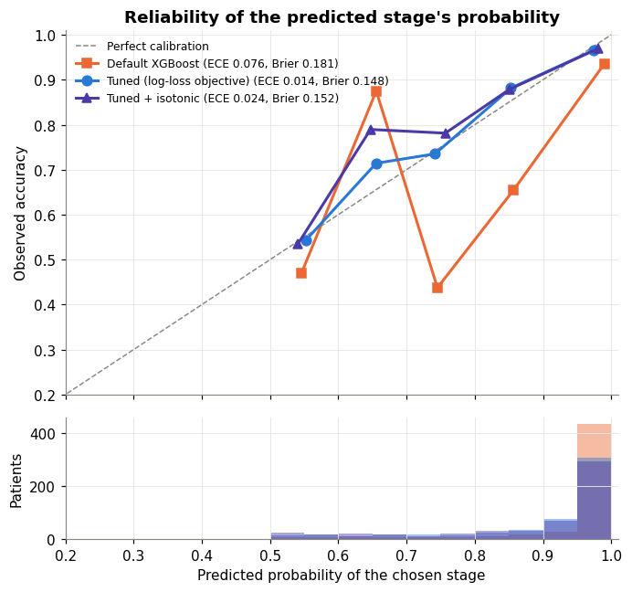

```python
def reliability(P, bins=10):
    conf, ok = P.max(1), (P.argmax(1) == y_te)
    edges = np.linspace(0, 1, bins + 1); xs, ys, ns = [], [], []
    for lo, hi in zip(edges[:-1], edges[1:]):
        m = (conf > lo) & (conf <= hi)
        if m.sum() >= 5:
            xs.append(conf[m].mean()); ys.append(ok[m].mean()); ns.append(m.sum())
    return np.array(xs), np.array(ys), np.array(ns)

fig, (ax, axh) = plt.subplots(2, 1, figsize=(6.4, 6), height_ratios=[3, 1], sharex=True)
ax.plot([0, 1], [0, 1], ls="--", color="#8a8984", lw=1, label="Perfect calibration")
for P, key, c, mk, lab in [(P_default, "xgb_default", BEFORE, "s", "Default XGBoost"),
                           (P_tuned, "xgb_tuned", AFTER, "o", "Tuned (log-loss objective)"),
                           (P_cal, "xgb_cal", "#4a3aa7", "^", "Tuned + isotonic")]:
    xs, ys, _ = reliability(P)
    ax.plot(xs, ys, marker=mk, color=c, lw=2, ms=7,
            label=f"{lab} (ECE {res[key]['ece']:.3f}, Brier {res[key]['brier']:.3f})")
    axh.hist(P.max(1), bins=20, range=(0, 1), color=c, alpha=0.45, histtype="stepfilled", label=lab)
ax.set_xlim(0.2, 1.01); ax.set_ylim(0.2, 1.01); ax.set_ylabel("Observed accuracy")
ax.legend(loc="upper left", fontsize=8)
ax.set_title("Reliability of the predicted stage's probability", fontweight="bold")
axh.set_xlabel("Predicted probability of the chosen stage"); axh.set_ylabel("Patients")
plt.tight_layout(); plt.savefig(f"{OUT}/topic6_fig4_calibration.png"); plt.show()
```

### Figure 5: Cross-validation stability before and after hyperparameter search

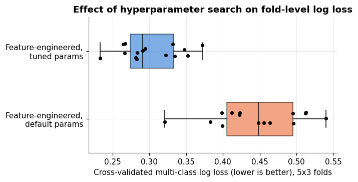

```python
fig, ax = plt.subplots(figsize=(6.4, 3.4))
data = [-cv_before, -cv_after]
bp = ax.boxplot(data, vert=False, widths=0.5, patch_artist=True, medianprops=dict(color="#0b0b0b"))
for patch, c in zip(bp["boxes"], [BEFORE, AFTER]):
    patch.set_facecolor(c); patch.set_alpha(0.6)
for k, d in enumerate(data):
    ax.scatter(d, np.full(d.size, k + 1) + rng.uniform(-0.12, 0.12, d.size), s=14, color="#0b0b0b", zorder=3)
ax.set_yticks([1, 2], ["Feature-engineered,\ndefault params", "Feature-engineered,\ntuned params"])
ax.set_xlabel("Cross-validated multi-class log loss (lower is better), 5x3 folds")
ax.set_title("Effect of hyperparameter search on fold-level log loss", fontweight="bold")
plt.tight_layout(); plt.savefig(f"{OUT}/topic6_fig5_cv_stability.png"); plt.show()
```

## 7. Exploratory data and trend analysis

### Figure 6: 24-hour systolic profiles by stage (mean with 95% CI), computed from the readings

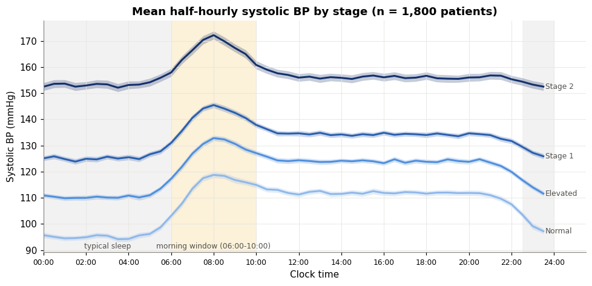

```python
prof = abpm.merge(patients[["pid", "target"]], on="pid").groupby(["target", "hour"]).sbp
mean, sem = prof.mean().unstack(0), prof.sem().unstack(0)
fig, ax = plt.subplots(figsize=(9, 4.4))
ax.axvspan(0, 6, color="#8a8984", alpha=0.10, lw=0); ax.axvspan(22.5, 24, color="#8a8984", alpha=0.10, lw=0)
ax.axvspan(6, 10, color="#eda100", alpha=0.15, lw=0)
for i in range(4):
    m, e = mean[i], 1.96 * sem[i]
    ax.fill_between(m.index, m - e, m + e, color=STAGE_COLORS[i], alpha=0.25, lw=0)
    ax.plot(m.index, m, color=STAGE_COLORS[i], lw=2, label=STAGES[i])
    ax.text(23.6, m.iloc[-1], STAGES[i], fontsize=8, va="center", color="#52514e")
ax.text(3, ax.get_ylim()[0] + 1.5, "typical sleep", ha="center", fontsize=8, color="#52514e")
ax.text(8, ax.get_ylim()[0] + 1.5, "morning window (06:00-10:00)", ha="center", fontsize=8, color="#52514e")
ax.set_xlim(0, 25.5); ax.set_xticks(range(0, 25, 2), [f"{h:02d}:00" for h in range(0, 25, 2)], fontsize=8)
ax.set_xlabel("Clock time"); ax.set_ylabel("Systolic BP (mmHg)")
ax.set_title(f"Mean half-hourly systolic BP by stage (n = {len(patients):,} patients)", fontweight="bold")
plt.tight_layout(); plt.savefig(f"{OUT}/topic6_fig6_circadian.png"); plt.show()
```

### Figure 7: Morning surge and nocturnal dipping by stage

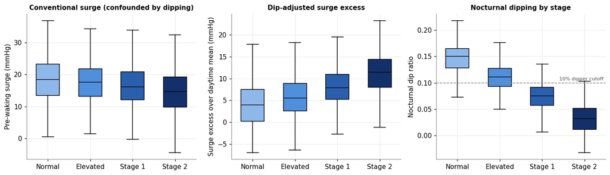

```
{'surge_prewake_median': [18.5, 17.6, 16.2, 14.6],
 'surge_trough_median': [25.8, 24.0, 22.6, 21.3],
 'surge_excess_median': [4.0, 5.5, 7.9, 11.4],
 'dip_median': [0.15, 0.111, 0.075, 0.032],
 'nondipper_share': [0.051, 0.329, 0.833, 0.993]}
```

```python
fig, (a1, a3, a2) = plt.subplots(1, 3, figsize=(13, 3.8))
for ax, col, lab in [(a1, "surge_prewake", "Pre-waking surge (mmHg)"),
                     (a3, "surge_excess", "Surge excess over daytime mean (mmHg)"),
                     (a2, "dip_ratio", "Nocturnal dip ratio")]:
    d = [df.loc[df.target == i, col].dropna() for i in range(4)]
    bp = ax.boxplot(d, widths=0.55, patch_artist=True, showfliers=False,
                    medianprops=dict(color="#0b0b0b"))
    for patch, c in zip(bp["boxes"], STAGE_COLORS):
        patch.set_facecolor(c)
    ax.set_xticks(range(1, 5), STAGES); ax.set_ylabel(lab)
a2.axhline(0.10, ls="--", color="#8a8984", lw=1); a2.text(4.45, 0.105, "10% dipper cutoff", fontsize=7.5, ha="right", color="#52514e")
a1.set_title("Conventional surge (confounded by dipping)", fontweight="bold", fontsize=10)
a3.set_title("Dip-adjusted surge excess", fontweight="bold", fontsize=10)
a2.set_title("Nocturnal dipping by stage", fontweight="bold", fontsize=10)
plt.tight_layout(); plt.savefig(f"{OUT}/topic6_fig7_surge_dip.png"); plt.show()

eda = {}
eda["surge_prewake_median"] = df.groupby("target").surge_prewake.median().round(1).tolist()
eda["surge_trough_median"] = df.groupby("target").surge_sleep_trough.median().round(1).tolist()
eda["surge_excess_median"] = df.groupby("target").surge_excess.median().round(1).tolist()
eda["dip_median"] = df.groupby("target").dip_ratio.median().round(3).tolist()
eda["nondipper_share"] = (df.assign(nd=df.dip_ratio < 0.10).groupby("target").nd.mean()).round(3).tolist()
eda
```

### Figure 8: Office spot-check versus ABPM: white-coat and masked patterns

Each patient's single office reading is compared with their daytime ABPM mean using the 2017 guideline correspondence (office ≥130/80 ↔ daytime ≥130/80). **White-coat**: office says hypertensive, ABPM does not. **Masked**: ABPM says hypertensive, office does not.

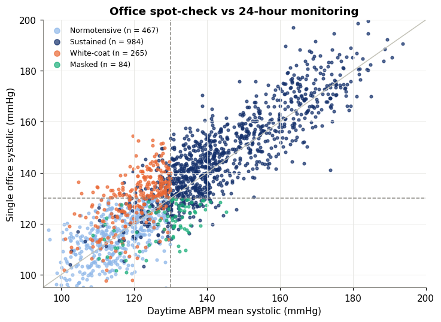

```
{'Sustained': 984, 'Normotensive': 467, 'White-coat': 265, 'Masked': 84}
```

```python
office_htn = (df.office_sbp >= 130) | (df.office_dbp >= 80)
abpm_htn = (df.sbp_day >= 130) | (df.dbp_day >= 80)
df["phenotype"] = np.select([office_htn & ~abpm_htn, ~office_htn & abpm_htn, office_htn & abpm_htn],
                            ["White-coat", "Masked", "Sustained"], "Normotensive")
eda["phenotype_counts"] = df.phenotype.value_counts().to_dict()
eda["office_rule_misclassified"] = int((pred_office != y_te).sum())
eda["office_vs_true_htn_disagree"] = float(((df.office_sbp >= 130) | (df.office_dbp >= 80)).ne(df.target >= 2).mean())
fig, ax = plt.subplots(figsize=(6.8, 5))
ph_col = {"Normotensive": "#8fb8ea", "Sustained": "#14306b", "White-coat": "#eb6834", "Masked": "#1baf7a"}
for ph, c in ph_col.items():
    m = df.phenotype == ph
    ax.scatter(df.sbp_day[m], df.office_sbp[m], s=9, color=c, alpha=0.7,
               label=f"{ph} (n = {m.sum()})")
ax.axvline(130, ls="--", color="#8a8984", lw=1); ax.axhline(130, ls="--", color="#8a8984", lw=1)
lim = [95, 200]; ax.plot(lim, lim, color="#c3c2b7", lw=1)
ax.set_xlim(lim); ax.set_ylim(lim)
ax.set_xlabel("Daytime ABPM mean systolic (mmHg)"); ax.set_ylabel("Single office systolic (mmHg)")
ax.legend(fontsize=8, loc="upper left", markerscale=2)
ax.set_title("Office spot-check vs 24-hour monitoring", fontweight="bold")
plt.tight_layout(); plt.savefig(f"{OUT}/topic6_fig8_office_vs_abpm.png"); plt.show()
eda["phenotype_counts"]
```

### Figure 9: Global feature attribution (mean |SHAP|, tuned model, holdout)

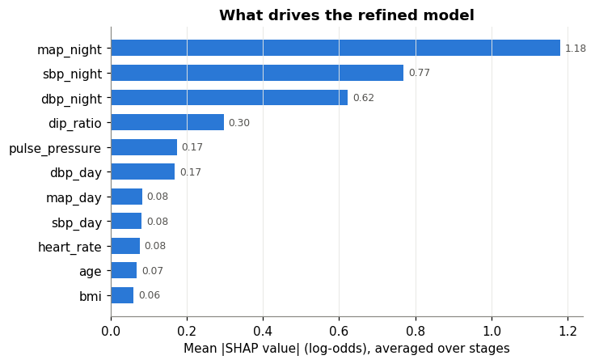

```
{'map_night': 1.180999994277954,
 'sbp_night': 0.7699999809265137,
 'dbp_night': 0.6230000257492065,
 'dip_ratio': 0.296999990940094,
 'pulse_pressure': 0.17299999296665192,
 'dbp_day': 0.16899999976158142}
```

```python
sv = explainer.shap_values(te[ENG])
sv = np.stack(sv, -1) if isinstance(sv, list) else sv  # (n, features, classes)
imp = pd.Series(np.abs(sv).mean(axis=(0, 2)), index=ENG).sort_values()
fig, ax = plt.subplots(figsize=(6.8, 4.2))
ax.barh(imp.index, imp.values, color="#2a78d6", height=0.65)
for yv, v in enumerate(imp.values):
    ax.text(v + imp.max() * 0.01, yv, f"{v:.2f}", va="center", fontsize=8, color="#52514e")
ax.set_xlabel("Mean |SHAP value| (log-odds), averaged over stages")
ax.set_title("What drives the refined model", fontweight="bold"); ax.grid(axis="y", visible=False)
plt.tight_layout(); plt.savefig(f"{OUT}/topic6_fig9_shap.png"); plt.show()
eda["shap_top"] = imp.sort_values(ascending=False).round(3).head(6).to_dict()
eda["shap_top"]
```

### Figure 10: Where the refined model errs (tuned model) (error rate by daytime systolic level)

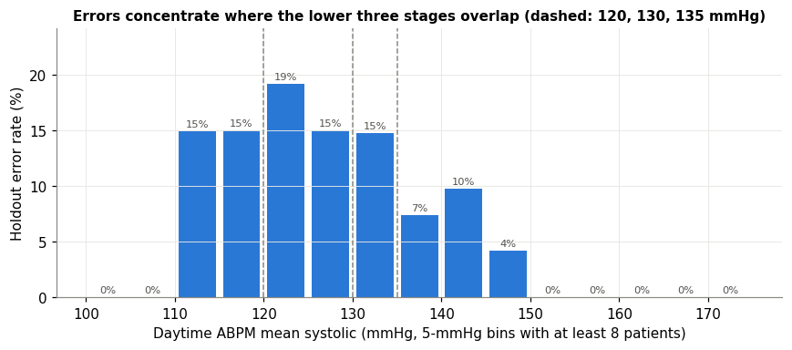

```
(0.1615720524017467, 0.05144694533762058, 0.6981132075471698)
```

```python
err = pd.DataFrame(dict(sbp=te.sbp_day.values, wrong=(P_tuned.argmax(1) != y_te)))
err["bin"] = pd.cut(err.sbp, np.arange(95, 191, 5))
rate = err.groupby("bin").wrong.agg(["mean", "size"])
rate = rate[rate["size"] >= 8]
mids = [b.mid for b in rate.index]
fig, ax = plt.subplots(figsize=(8, 3.6))
ax.bar(mids, rate["mean"] * 100, width=4.2, color="#2a78d6")
for m_, v in zip(mids, rate["mean"].values):
    ax.text(m_, v * 100 + 0.4, f"{v:.0%}", ha="center", fontsize=7.5, color="#52514e")
for x_ in [120, 130, 135]:
    ax.axvline(x_, ls="--", color="#8a8984", lw=1)
ax.set_xlabel("Daytime ABPM mean systolic (mmHg, 5-mmHg bins with at least 8 patients)")
ax.set_ylabel("Holdout error rate (%)")
ax.set_ylim(0, rate["mean"].max() * 100 + 5)
ax.set_title("Errors concentrate where the lower three stages overlap (dashed: 120, 130, 135 mmHg)", fontweight="bold", fontsize=10)
plt.tight_layout(); plt.savefig(f"{OUT}/topic6_fig10_errors.png"); plt.show()
near = (np.abs(te.sbp_day.values - 130) <= 5) | (np.abs(te.sbp_day.values - 120) <= 5)
eda["err_near_boundary"] = float(err.wrong[near].mean()); eda["err_far"] = float(err.wrong[~near].mean())
eda["share_errors_near_boundary"] = float(err.wrong[near].sum() / max(err.wrong.sum(), 1))
eda["err_near_boundary"], eda["err_far"], eda["share_errors_near_boundary"]
```

### Follow-up experiment: does a morning-surge feature help?

The exploratory analysis suggests adding the surge features. They are added to the *same* tuned hyperparameters so any change is attributable to the features. The decision came from cross-validation in Section 5; the holdout result below is descriptive.

```python
xgb_surge = clone(xgb_tuned).fit(tr[SURGE], y_tr)
P_surge = xgb_surge.predict_proba(te[SURGE])
res["xgb_surge"] = evaluate("+ Morning-surge features", P_surge.argmax(1), P_surge)
cvs = cross_val_score(clone(xgb_tuned), tr[SURGE], y_tr, cv=rcv, scoring="neg_log_loss", n_jobs=1)
eda["surge_experiment"] = dict(holdout={k: round(res["xgb_surge"][k], 4) for k in
                                        ["accuracy", "macro_f1", "crisis_recall", "brier", "ece"]},
                               cv_logloss=[float(-cvs.mean()), float(cvs.std())])
eda["surge_experiment"]
```

```
{'holdout': {'accuracy': 0.9056,
  'macro_f1': 0.9059,
  'crisis_recall': 0.9704,
  'brier': 0.1478,
  'ece': 0.02},
 'cv_logloss': [0.29885154476631776, 0.0379505856729736]}
```

### Subgroup check (sex and age band)

```python
sub = te.assign(correct=(P_tuned.argmax(1) == y_te),
                age_band=pd.cut(te.age, [0, 45, 65, 120], labels=["<45", "45-64", "65+"]))
ci95 = lambda p, n: 1.96 * np.sqrt(p * (1 - p) / n)
subgroups = {f"sex={k}": [float(v.mean()), int(v.size), float(ci95(v.mean(), v.size))] for k, v in sub.groupby("sex").correct}
subgroups.update({f"age={k}": [float(v.mean()), int(v.size), float(ci95(v.mean(), v.size))] for k, v in sub.groupby("age_band").correct})
eda["subgroups"] = subgroups
subgroups
```

```
{'sex=F': [0.9068100358422939, 279, 0.034111176693743445],
 'sex=M': [0.896551724137931, 261, 0.03694750538749816],
 'age=<45': [0.8602150537634409, 93, 0.0704771475160658],
 'age=45-64': [0.8978328173374613, 323, 0.033029975895090664],
 'age=65+': [0.9435483870967742, 124, 0.040622392165634874]}
```

## 8. Save metrics for the report

```python
metrics.update(results=res, eda=eda, n_train=int(len(tr)), n_test=int(len(te)),
               test_class_counts=np.bincount(y_te).tolist())
with open(f"{OUT}/topic6_metrics.json", "w") as f:
    json.dump(metrics, f, indent=2, default=lambda o: o.tolist() if hasattr(o, "tolist") else str(o))
summary.astype(float).round(3)
```

| name | accuracy | macro_f1 | crisis_recall | macro_roc_auc | brier | ece | latency_ms |
| --- | --- | --- | --- | --- | --- | --- | --- |
| Office AHA rule (single reading) | 0.543 | 0.521 | 0.956 | NaN | NaN | NaN | 0.168 |
| ABPM guideline rule (daytime mean) | 0.615 | 0.588 | 0.993 | NaN | NaN | NaN | 0.168 |
| Logistic regression | 0.883 | 0.884 | 0.948 | 0.980 | 0.182 | 0.056 | 2.197 |
| Default XGBoost | 0.889 | 0.889 | 0.970 | 0.980 | 0.181 | 0.076 | 3.335 |
| + Feature engineering | 0.889 | 0.889 | 0.970 | 0.980 | 0.176 | 0.065 | 4.166 |
| + Hyperparameter search | 0.902 | 0.902 | 0.970 | 0.984 | 0.148 | 0.014 | 4.178 |
| + Isotonic calibration | 0.900 | 0.900 | 0.970 | 0.982 | 0.152 | 0.024 | 25.412 |

## 9. Export the refined model for the API

The pipeline that was evaluated is the pipeline that is served: the tuned XGBoost trained on the 1,260 training patients (not refit on the holdout, so the reported holdout figures describe exactly this artifact). The model is written in XGBoost's native JSON format rather than as a pickle, together with a model card and a small parity fixture (raw readings, features and probabilities for 25 holdout patients) that the backend tests use to prove the API reproduces the notebook.

```python
import hashlib, datetime
MODEL_DIR = "backend/models_saved"; FIX_DIR = "backend/tests/fixtures"
os.makedirs(MODEL_DIR, exist_ok=True); os.makedirs(FIX_DIR, exist_ok=True)

xgb_tuned.save_model(f"{MODEL_DIR}/abpm_xgb_refined.json")
sha = hashlib.sha256(open(f"{MODEL_DIR}/abpm_xgb_refined.json", "rb").read()).hexdigest()
card = dict(
    model_id="abpm-xgb-refined-v1", created_utc=datetime.datetime.utcnow().isoformat(timespec="seconds"),
    sha256=sha, stages=STAGES, features=ENG, random_state=RANDOM_STATE, hyperparameters=best_params,
    training=dict(n_patients=int(len(tr)), data="synthetic ABPM cohort, 48 half-hourly readings per patient"),
    holdout=dict(n=int(len(te)), **{k: float(res["xgb_tuned"][k]) for k in
                 ["accuracy", "macro_f1", "crisis_recall", "macro_roc_auc", "brier", "ece"]},
                 accuracy_ci95=metrics["ci"]["xgb_tuned"]["accuracy"]),
    selection=metrics["selection"]["decisions"],
    subgroup_accuracy=eda["subgroups"],
    intended_use="decision support demo; classify a patient's 24-hour ABPM record into an ACC/AHA stage with explanation",
    limitations=["trained and tested on simulated data whose labels come from the same generator as the features",
                 "not clinically validated; not for diagnosis or treatment decisions",
                 "lowest accuracy for patients under 45 and for the Elevated stage",
                 "errors concentrate within +/-5 mmHg of stage cut-points"],
    versions=metrics["selection"]["environment"])
json.dump(card, open(f"{MODEL_DIR}/abpm_model_card.json", "w"), indent=2)

nan2none = lambda a: [None if (isinstance(v, float) and np.isnan(v)) else float(v) for v in a]
fixture = []
for n, pid_ in enumerate(te.pid.values[:25]):
    g = abpm[abpm.pid == pid_]; p = patients[patients.pid == pid_].iloc[0]; row = te[te.pid == pid_].iloc[0]
    fixture.append(dict(
        age=float(p.age), bmi=float(p.bmi), wake=float(p.wake), bed=float(p.bed),
        readings=[dict(hour=float(h), sbp=s, dbp=d, hr=r, awake=bool(a))
                  for h, s, d, r, a in zip(g.hour, nan2none(g.sbp), nan2none(g.dbp), nan2none(g.hr), g.awake)],
        features={f: float(row[f]) for f in ENG},
        probabilities=[float(v) for v in P_tuned[list(te.pid.values).index(pid_)]],
        stage=int(P_tuned[list(te.pid.values).index(pid_)].argmax())))
json.dump(fixture, open(f"{FIX_DIR}/abpm_parity.json", "w"))
print("saved", sha[:12], "| fixture patients:", len(fixture))
```

```
saved 88f990696857 | fixture patients: 25
```

## References

Bergstra, J., & Bengio, Y. (2012). Random search for hyper-parameter optimization. *Journal of Machine Learning Research, 13*, 281–305.

Chen, T., & Guestrin, C. (2016). XGBoost: A scalable tree boosting system. In *Proceedings of the 22nd ACM SIGKDD International Conference on Knowledge Discovery and Data Mining* (pp. 785–794). https://doi.org/10.1145/2939672.2939785

Kario, K., Pickering, T. G., Umeda, Y., Hoshide, S., Hoshide, Y., Morinari, M., Murata, M., Kuroda, T., Schwartz, J. E., & Shimada, K. (2003). Morning surge in blood pressure as a predictor of silent and clinical cerebrovascular disease in elderly hypertensives. *Circulation, 107*(10), 1401–1406. https://doi.org/10.1161/01.CIR.0000056521.67546.AA

Lundberg, S. M., Erion, G., Chen, H., DeGrave, A., Prutkin, J. M., Nair, B., Katz, R., Himmelfarb, J., Bansal, N., & Lee, S.-I. (2020). From local explanations to global understanding with explainable AI for trees. *Nature Machine Intelligence, 2*(1), 56–67. https://doi.org/10.1038/s42256-019-0138-9

Whelton, P. K., Carey, R. M., Aronow, W. S., et al. (2018). 2017 ACC/AHA/AAPA/ABC/ACPM/AGS/APhA/ASH/ASPC/NMA/PCNA guideline for the prevention, detection, evaluation, and management of high blood pressure in adults. *Journal of the American College of Cardiology, 71*(19), e127–e248. https://doi.org/10.1016/j.jacc.2017.11.006